# Exercise 2 : Vector data, Administrative boudaries and Open Street Maps

Then we use st_buffer to build a circle around the centroid and crop only that area to visualize more in detail.

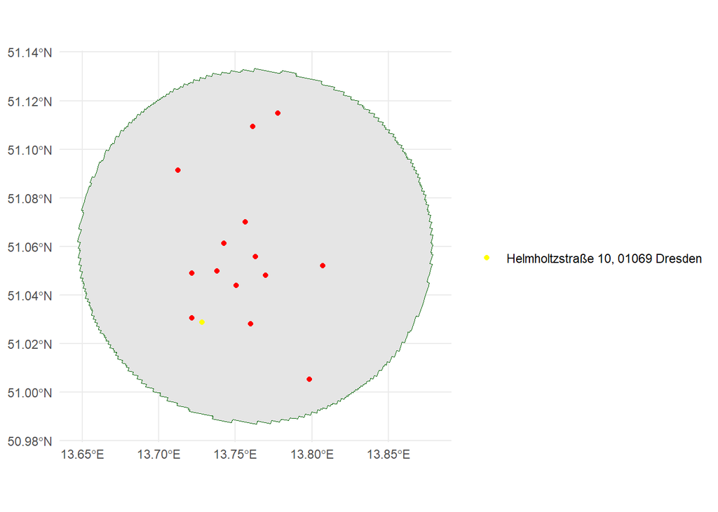

```r
## using the center of the area covered by trams

center <- st_centroid(area_tram_sf)

# Create a buffer around the centroid

buffer_distance <- 8000 # in meters
buffered_area <- st_buffer(center, dist = buffer_distance)



ggplot() +
  geom_sf(data=buffered_area, colour="darkgreen")+
  geom_sf(data=market_sf, colour="red")+
  geom_sf(data = hub_sf,aes(fill = "Helmholtzstraße 10, 01069 Dresden"), color = "yellow") +
  labs(fill="")+
  theme_minimal()
```

We can compute the shortest path to Alaunplatz market from the office using osrmRoute():

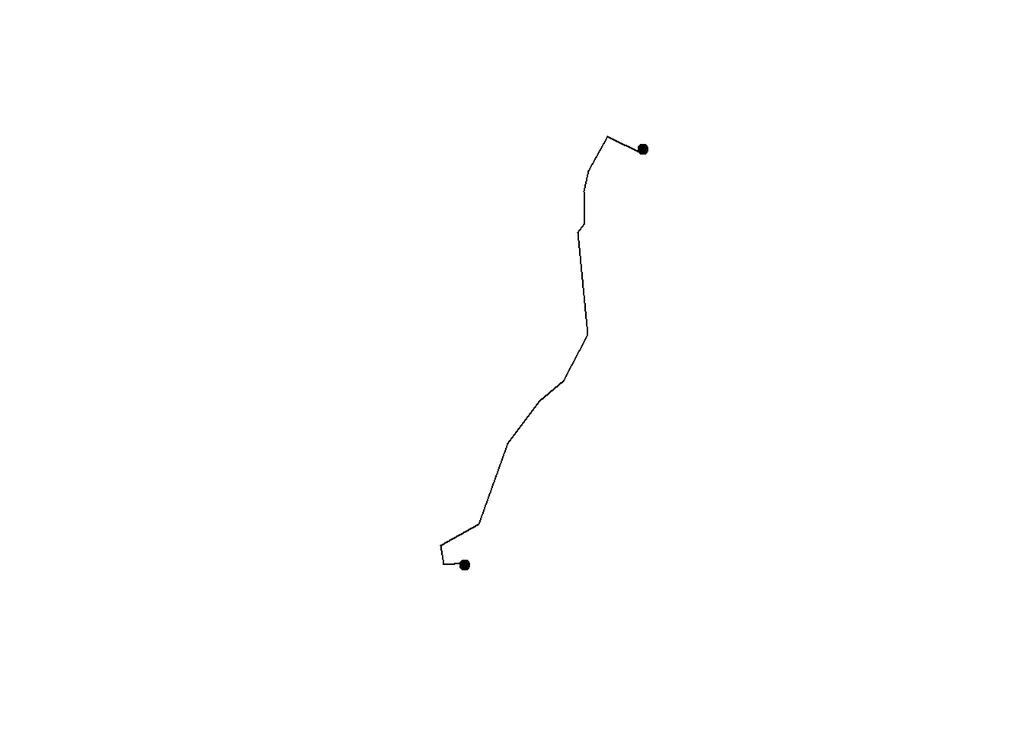

```r
## take location of alaun platz from the market street

alaun_platz <- market_sf |>
filter(strasse == "Alaunplatz")

route <- osrmRoute(src = hub_sf , dst = alaun_platz)

##let´s plot the route object

plot(st_geometry(route))
plot(st_geometry(hub_sf), pch = 20, add = T, cex = 1.5)
plot(st_geometry(alaun_platz), pch = 20, add = T, cex = 1.5)
```

```r
str(route) ## is a LINESTRING
```

```
## Classes 'sf' and 'data.frame':   1 obs. of  5 variables:
##  $ src     : chr "1"
##  $ dst     : chr "1"
##  $ duration: num 11.8
##  $ distance: num 6.11
##  $ geometry:sfc_LINESTRING of length 1; first list element:  'XY' num [1:14, 1:2] 13.7 13.7 13.7 13.7 13.7 ...
##  - attr(*, "sf_column")= chr "geometry"
##  - attr(*, "agr")= Factor w/ 3 levels "constant","aggregate",..: NA NA NA NA
##   ..- attr(*, "names")= chr [1:4] "src" "dst" "duration" "distance"
```

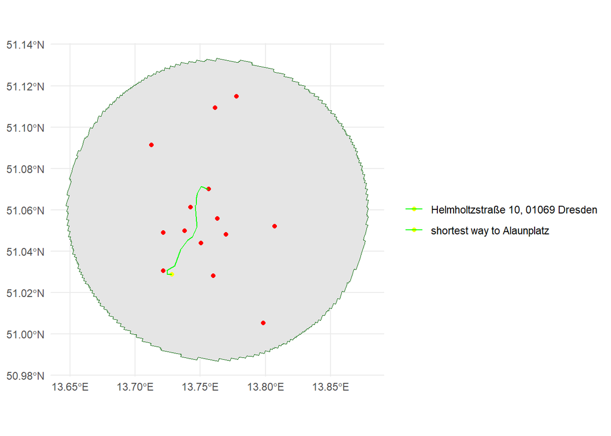

```r
## and now look at it intoour city ggplot map



ggplot() +
  geom_sf(data=buffered_area, colour="darkgreen")+
  geom_sf(data=market_sf, colour="red")+
  geom_sf(data = hub_sf,aes(fill = "Helmholtzstraße 10, 01069 Dresden"), color = "yellow") +
  geom_sf(data = route,aes(fill = "shortest way to Alaunplatz"), color = "green") +
  labs(fill="")+
  theme_minimal()
```

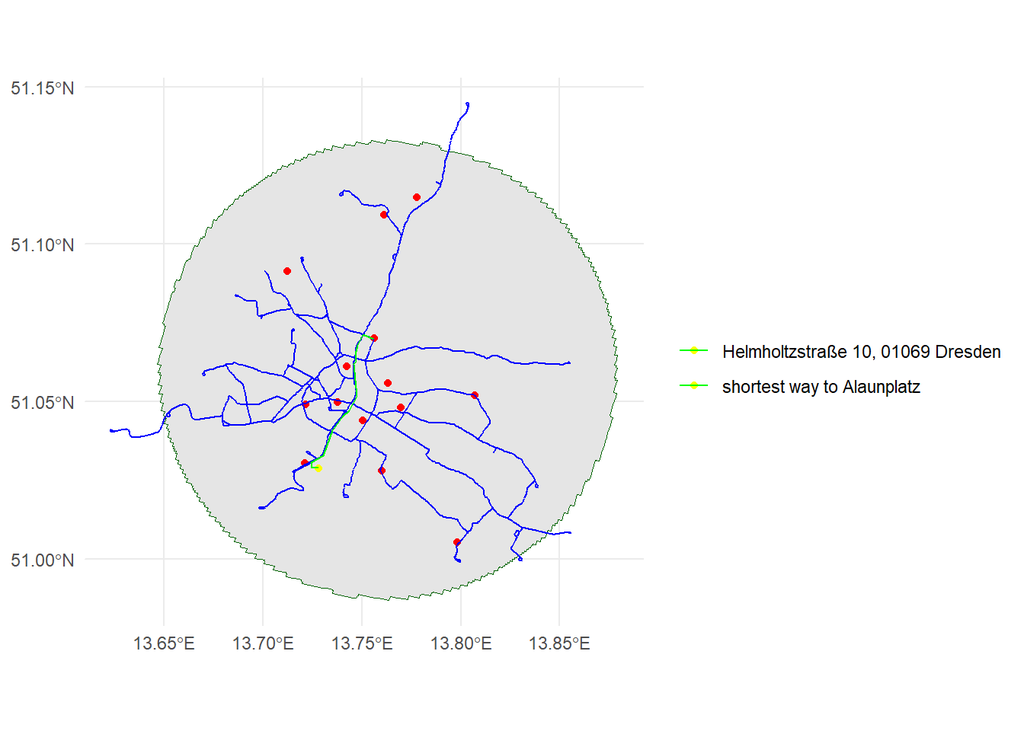

```r
## we can also check how the shortest route compare with the tram lines


ggplot() +
  geom_sf(data=buffered_area, colour="darkgreen")+
  geom_sf(data=market_sf, colour="red")+
  geom_sf(data=tram_sf, colour= "blue")+
  geom_sf(data = hub_sf,aes(fill = "Helmholtzstraße 10, 01069 Dresden"), color = "yellow") +
  geom_sf(data = route,aes(fill = "shortest way to Alaunplatz"), color = "green") +
  labs(fill="")+
  theme_minimal()
```

It is visible how the shortest route is a tram line, let´s discover which one.

We can use a spatial join to find spatial matches between the coordinates of the LINESTRING object

```r
## use st_intersection()



intersection <- st_intersection(route, tram_sf)


## we can look at the structure of the output data from the intersection function



table(intersection$strasse)
```

```
##
##      Bautzner Straße          Bischofsweg       Grunaer Straße
##                    1                    1                    1
## Königsbrücker Straße         Wiener Platz
##                    3                    1
```

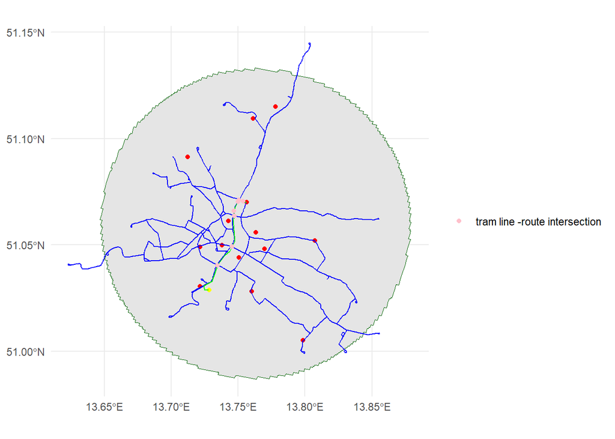

```r
## and vizualize it in our plot


ggplot() +
  geom_sf(data=buffered_area, colour="darkgreen")+
  geom_sf(data=market_sf, colour="red")+
  geom_sf(data=tram_sf, colour= "blue")+
  geom_sf(data = hub_sf, color = "yellow") +
  geom_sf(data = route, color = "green") +
  geom_sf(data = intersection,aes(fill = "tram line -route intersection"), show.legend = "point", color = "pink") +
  labs(fill="")+
  theme_minimal()
```